# Two Species ITQ

Ernesto Carrella

October 9, 2015

Here I test the effects of the newly implemented [multi-species ITQ quota system](http://carrknight.github.io/assets/oxfish/itqs/itq.pdf).

The biology set up is as follows: there are 2 species of fish, specie 0 (the red one) is abundant, specie 1 (the blue one) is rare but they coexist in every cell of the map. The ratio of biomass is about 70 red to 30 blue.

The red fish is worth 10$ a unit, the blue fish is worthless.

[figure not shown]

There is an ITQ system in place. Yearly each fisher gets 4500 units of quotas for red and 500 units of quotas for blue. The proportion of quota then is 90 red to 10 blue, unbalanced compared to the biomass ratios.  
The following results emerge:

These are the time series of the quota prices over a 10 year simulation:

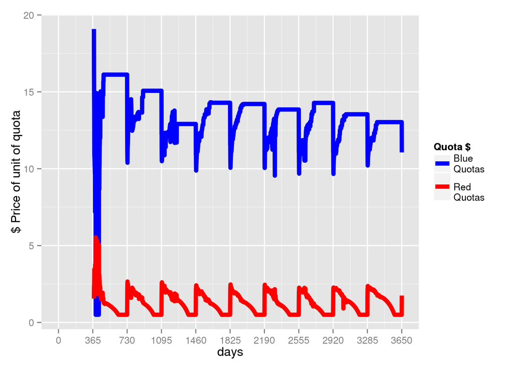

These are the catches per year for the 10 years of simulation:

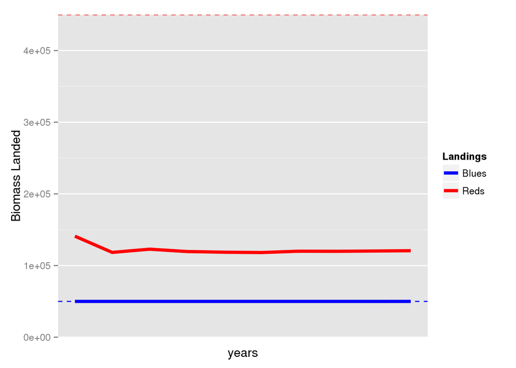

The dashed lines are the quotas given that year. About 100% of the blue quotas are consumed, but only about 30% of the red ones are